# Homework 1

林妤真 b04b01036

#### ——————————————————————————————————————————————————–

#### • Self practice (Lange 2002 Exercise 2-2) Suppose in the Hardy-Weinberg model for and autosomal locus that the genotype frequencies for the two sexes differ:

###### Fi:Female

###### A1A1:uf

###### A1A2:vf

###### A2A2:wf

###### Fi:Male

###### A1A1:um

###### A1A2:vm

###### A2A2:wm

#### Define the probability

```r
uf <- 0.1
vf <- 0.2
wf <- 0.7

um <- 0.5
vm <- 0.3
wm <- 0.2
```

#### (a) Compute the frequencies of the genotypes in Fi+1

```r
A1A1 <- (uf + vf/2)*(um + vm/2)
A1A2 <- (uf + vf/2)*(vm/2 + wm) + (um + vm/2)*(vf/2 + wf)
A2A2 <- (vf/2 + wf)*(vm/2 + wm)

# 此計算方式的基因頻率總和應為1，此計算方式才是正確的。
A1A1+A1A2+A2A2
```

```
## [1] 1
```

#### (b-1) Use the “random-mating simulator” as in the previous practice and the χ2-test to confirm your result.

#### Random-mating simulator

```r
p <- c(A1A1, A1A2, A2A2) #prob in x

new.x <- c()

for (i in 1:1000){
x <- sample(c("A1A1", "A1A2", "A2A2"), prob=p, size=2, replace=TRUE) #只抽2人
x1 <- sample(c(substr(x[1],1,2), substr(x[1],3,4)), size=1) #第一個親本
x2 <- sample(c(substr(x[2],1,2), substr(x[2],3,4)), size=1) #第二個親本 設變數讓數字固定下來
new.x[i] <- paste0(sort(c(x1, x2)), collapse="") # sort 的東西要在同個向量
}

new.x
```

[output not shown]

[output cut: 97 more lines]

#### (b-2) χ2-test

```r
result.table <- as.data.frame(table(new.x))
result.table
```

```
##   new.x Freq
## 1  A1A1  172
## 2  A1A2  510
## 3  A2A2  318
```

```r
result.chi <- chisq.test(c(result.table[1,2],result.table[2,2],result.table[3,2]), # 模擬出的後代基因頻率
                         p=c((A1A1+A1A2/2)^2, 2*(A1A1+A1A2/2)*(A2A2+A1A2/2), (A2A2+A1A2/2)^2)) # 理論上的後代基因頻率
result.chi
```

```
##
##  Chi-squared test for given probabilities
##
## data:  c(result.table[1, 2], result.table[2, 2], result.table[3, 2])
## X-squared = 1.8179, df = 2, p-value = 0.403
```

```r
result.chi$p.value # 結果發現 p-value 大於 0.05，代表我們模擬的結果與理論上的後代基因頻率沒有顯著差異，確認模擬結果正確。
```

```
## [1] 0.4029565
```

#### (c) How long does it take genotype frequencies to stabilize at their Hardy-Weinberg values?

當 p.value 大於 0.05 時，代表前一代與後一代間的基因頻率沒有顯著差異，即已達到哈溫平衡。

```r
# Define the probability
# 第一代 F1
uf <- 0.1
vf <- 0.2
wf <- 0.7

um <- 0.5
vm <- 0.3
wm <- 0.2

# Compute the frequencies of the genotypes in Fi+1
# 第二代 F2
A1A1 <- (uf + vf/2)*(um + vm/2)
A1A2 <- (uf + vf/2)*(vm/2 + wm) + (um + vm/2)*(vf/2 + wf)
A2A2 <- (vf/2 + wf)*(vm/2 + wm)

# How long does it take genotype frequencies to stabilize at their Hardy-Weinberg values?
k = 10 # randomly set k generations to run the "random-mating simulator"
for(j in 1:k){
  p <- c(A1A1, A1A2, A2A2) #prob in x
  new.x <- c()
  for (i in 1:1000){
  x <- sample(c("A1A1", "A1A2", "A2A2"), prob=p, size=2, replace=TRUE) #只抽2人
  x1 <- sample(c(substr(x[1],1,2), substr(x[1],3,4)), size=1) #第一個親本
  x2 <- sample(c(substr(x[2],1,2), substr(x[2],3,4)), size=1) #第二個親本 設變數讓數字固定下來
  new.x[i] <- paste0(sort(c(x1, x2)), collapse="") # sort 的東西要在同個向量
  }
  result.table <- as.data.frame(table(new.x))
  # 比較這一代(A1A1, A1A2, A2A2) 與新算出的下一代(result.table) 是否有顯著差異
  result.chi <- chisq.test(c(result.table[1,2],result.table[2,2],result.table[3,2]), p=c(A1A1, A1A2, A2A2))

  if (result.chi$p.value > 0.05){
    # 因為第一代並不是在loop中算的，所以為 j+1 generations
    print(paste("It takes",j+1,"generation(s) to stabilize at their Hardy-Weinberg values."))
    break
  }else{
    A1A1 <- result.table[1,2] / 1000
    A1A2 <- result.table[2,2] / 1000
    A2A2 <- result.table[3,2] / 1000
  }
}
```

```
## [1] "It takes 3 generation(s) to stabilize at their Hardy-Weinberg values."
```

#### ——————————————————————————————————————————————————–

#### • Self practice (HWE for X-linker loci)

###### F1: Female 1/2 A1A1 + 1/2 A1A2

###### Male 1/2 A1 + 1/2 A2

###### F2: Female 3/8 A1A1 + 1/2 A1A2 + 1/8 A2A2

###### Male 3/4 A1 + 1/4 A2

Accordingly, the A1 allele frequencies for the female (qn) and the male (rn) in the nth generation can be derived from the allele frequencies for the female (qn−1) and the male (rn−1) in the n − 1th generation.

qn = 1/2(rn−1+qn−1) rn = qn−1

#### r0(=rn.1)=0.5 and q0(=qn.1)=0.5

We start from r0(=rn.1)=0.5 and q0(=qn.1)=0.5 and simulate to observe the zigzag-pattern convergence.

```r
r <- c()
q <- c()

rn.1 <- 0.5
qn.1 <- 0.5

for ( i in 1:10){
  qn = (1/2) * (rn.1+qn.1) # 以 rn.1 代表rn−1
  rn = qn.1

  rn.1 <- rn
  qn.1 <- qn

  r[i] <- rn.1
  q[i] <- qn.1
}

r
```

```
##  [1] 0.5 0.5 0.5 0.5 0.5 0.5 0.5 0.5 0.5 0.5
```

```r
q
```

```
##  [1] 0.5 0.5 0.5 0.5 0.5 0.5 0.5 0.5 0.5 0.5
```

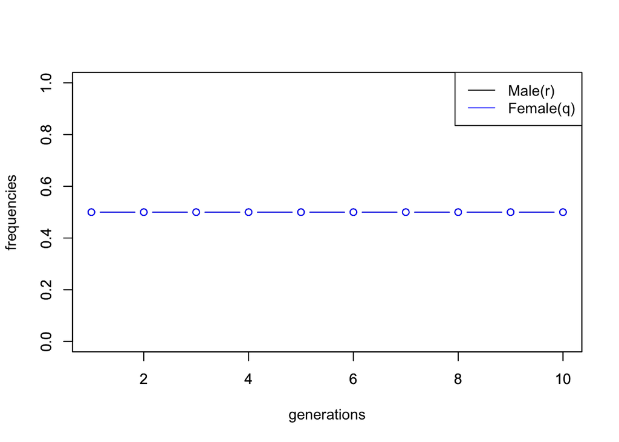

```r
plot(c(1:length(r)), r, col = "black", ylim=c(0,1), xlab="generations", ylab="frequencies")
lines(c(1:length(r)), r, type="b", lwd=1, lty=1, col="black")
par(new = TRUE) #New plot
plot(c(1:length(q)), q, col = "blue", ylim=c(0,1),xlab="", ylab="")
lines(c(1:length(q)), q, type="b", lwd=1, lty=1, col="blue")
legend("topright",c("Male(r)","Female(q)"), col=c("black","blue"), lty=1)
```

Whwn I start from r0(=rn.1)=0.5 and q0(=qn.1)=0.5, I can’t observe the zigzag-pattern convergence. Thus I run it again with r0(=rn.1)=0.2 and q0(=qn.1)=0.8

#### r0(=rn.1)=0.2 and q0(=qn.1)=0.8

We start from r0(=rn.1)=0.2 and q0(=qn.1)=0.8 and simulate to observe the zigzag-pattern convergence.

```r
r <- c()
q <- c()

rn.1 <- 0.2
qn.1 <- 0.8

for ( i in 1:10){
  qn = (1/2) * (rn.1+qn.1) # 以 rn.1 代表rn−1
  rn = qn.1

  rn.1 <- rn
  qn.1 <- qn

  r[i] <- rn.1
  q[i] <- qn.1
}

r
```

```
##  [1] 0.8000000 0.5000000 0.6500000 0.5750000 0.6125000 0.5937500 0.6031250
##  [8] 0.5984375 0.6007813 0.5996094
```

```r
q
```

```
##  [1] 0.5000000 0.6500000 0.5750000 0.6125000 0.5937500 0.6031250 0.5984375
##  [8] 0.6007813 0.5996094 0.6001953
```

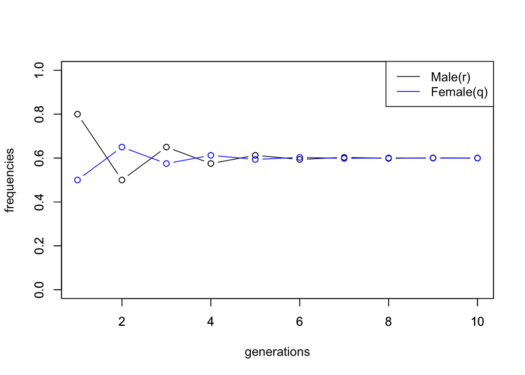

```r
plot(c(1:length(r)), r, col = "black", ylim=c(0,1), xlab="generations", ylab="frequencies")
lines(c(1:length(r)), r, type="b", lwd=1, lty=1, col="black")
par(new = TRUE) #New plot
plot(c(1:length(q)), q, col = "blue", ylim=c(0,1),xlab="", ylab="")
lines(c(1:length(q)), q, type="b", lwd=1, lty=1, col="blue")
legend("topright",c("Male(r)","Female(q)"), col=c("black","blue"), lty=1)
```